# High performance pipelines

# 5. Managing pipelines with package : *targets*

https://github.com/ropensci/targets

Now, what if you have a very complex pipeline with numerous steps and dependencies that each require multiple adjustments for calibration, such as bayesian data analysis, deep/machine learning, statistical genomics, etc.?

*targets* was built on the premise that R currently falls behind in the pipeline community, mainly because of its different culture : work in a single or few files and going through it from top to bottom, versus building your function ecosystem and compiling.

Running your functions in parallel might win you some time, but the biggest time sink in complex computing problems is often the fact that you always need to re-run code while making sure to track your changes everywhere, leading to reproducibility issues and headaches.

ex: re-calibrate a training set, change a prior, etc.

In those cases, to favor performance and reproducibility, it might be interesting to use a workflow manager such as **targets**, which can feel highly different to literate progamming styles often used in Rmarkdown.

The strength of this approach is that it de-clutters complex scripts, while mapping the dependencies between each function, tracking what needs and doesn’t need to be ran depending on changes made to the pipeline.

Mapping the depencies between functions allows the creation of multiple branches through the workflow which can be run in parallel by multiple workers using *future*, which is especially useful if you have access to multiple clusters, of if some of your processing does not allow for within-function parallelism.

For a further dive into the philosophy of targets, see this [talk by Will Landau presenting the *targets* library](https://www.youtube.com/watch?v=FODSavXGjYg&t) where he summarises the strengths of this approach as follow :  
- scale up the work you need  
- skip the work you don’t  
- see evidence of reproducibility

By building relevant targets based on functions, you will:  
- define relationships among inputs and outputs  
- help *targets* decide which tasks to run or skip  
- break down complicated ideas into manageable pieces  
- make the code easier to read

So how do we build a *target* pipeline?

**Structure**: The structure is very flexible, the only real requirement is a _targets.R script, or a target markdown document. Then you need to define your functions, which can be done in another script to prevent clutter. And finally you need to tell targets which libraries are needed and give it a list of targets.

**Let’s build a pipeline to investigate the penguins dataset from the *palmerpenguins* library.**

**First**, create a new R script called _targets.R and load the *targets* library. If you want to visualize your pipeline, load *visNetwork* and if you want to use future, also include *future* and set your plan() function.

```r
library(targets)
library(visNetwork)
library(future)
plan(multisession, workers = 2)
```

Then, either define your custom functions or load them from a separate script script (ex. functions.R) using the source() function.

```r
# clean data
data_clean = function(x,
                      species = NULL,
                      island = NULL){

  if(!identical(x,penguins)){
    return("The only acceptable input is penguins")
  }

  res = x %>%
    drop_na()

  if(!is.null(species)){
     if(species %in% c("Adelie","Chinstrap","Gentoo")){
       res = res %>%
        filter(species == species)
       }else{
         return("Accepted species are Adelie, Chinstrap and Gentoo")
       }
    }

  if(!is.null(island)){
    if(island %in% c("Biscoe","Dream","Torgersen")){
      res = res %>%
        filter(island == island)
    }else{
        return("Accepted islands are Biscoe, Dream and Torgersen")
      }
  }

  return(res)
}
```

```
## Establish _targets.R and _targets_r/globals/function1.R.
```

Specify to targets which libraries are required to run the pipeline

```r
tar_option_set(packages = c("tidyverse","palmerpenguins","future","furrr"))
```

```
## Establish _targets.R and _targets_r/globals/options.R.
```

Now define your targets within a list.  
To create a target, use the tar_target() function, where the first argument is the name of the target to create, and the second is the function that will be used to create this target. Notice that you should simply call a prior target’s name in the call for the next ones. This is how *targets* sees dependencies. This list should be the final element in the _targets.R file.

```r
list(
  tar_target(data, palmerpenguins::penguins),
  tar_target(clean, data_clean(data))
)
```

```
## Establish _targets.R and _targets_r/targets/list_def.R.
```

After saving this file, you should be able to see your pipeline by running tar_visnetwork() in the R console (do not write it in your _target.R file). You will see that *targets* automatically knows about the dependencies in your pipeline and maps them accordingly.

```r
tar_visnetwork()
```

[interactive chart not shown]

Then, to compile this pipeline, simply use tar_make() and it will run all required targets, skipping all the ones that are already up-to-date.

```r
tar_make()
```

```
## * start target data
## * built target data
## * start target clean
## * built target clean
## * end pipeline
## Messages d'avis :
## 1: le package 'targets' a été compilé avec la version R 4.1.2
## 2: le package 'palmerpenguins' a été compilé avec la version R 4.1.2
## 3: le package 'future' a été compilé avec la version R 4.1.2
## 4: le package 'furrr' a été compilé avec la version R 4.1.2
## 5: 1 targets produced warnings. Run tar_meta(fields = warnings) for the messages.
```

Now, you can visualize your network again to see if all your pipeline was able to run without issues.

```r
tar_visnetwork()
```

[interactive chart not shown]

When targets are correctly executed, their results can be called as regular R objects using the tar_read function

```r
tar_read(clean)
```

```
## # A tibble: 333 x 8
##    species island    bill_length_mm bill_depth_mm flipper_length_mm body_mass_g
##    <fct>   <fct>              <dbl>         <dbl>             <int>       <int>
##  1 Adelie  Torgersen           39.1          18.7               181        3750
##  2 Adelie  Torgersen           39.5          17.4               186        3800
##  3 Adelie  Torgersen           40.3          18                 195        3250
##  4 Adelie  Torgersen           36.7          19.3               193        3450
##  5 Adelie  Torgersen           39.3          20.6               190        3650
##  6 Adelie  Torgersen           38.9          17.8               181        3625
##  7 Adelie  Torgersen           39.2          19.6               195        4675
##  8 Adelie  Torgersen           41.1          17.6               182        3200
##  9 Adelie  Torgersen           38.6          21.2               191        3800
## 10 Adelie  Torgersen           34.6          21.1               198        4400
## # ... with 323 more rows, and 2 more variables: sex <fct>, year <int>
```

Let’s add a few steps to the pipeline to make it more complex.  
Let’s look at how body mass influences bill length for different species and islands in the dataset. We will make a different pipeline branch for two species and make a figure from each branch. All branches will be ran in parallel using the tar_make_future() function.

First, let’s build our plot function and add it to our functions script.

```r
tar_option_set(packages = c("tidyverse","palmerpenguins","future","furrr"))
```

```
## Establish _targets.R and _targets_r/globals/options2.R.
```

```r
# clean data
data_clean = function(x,
                      sp = NULL,
                      isl = NULL){

  if(!identical(x,penguins)){
    return("The only acceptable input is penguins")
  }

  res = x %>%
    drop_na()

  if(!is.null(sp)){
     if(sp %in% c("Adelie","Chinstrap","Gentoo")){
       res = res %>%
        filter(species == sp)
       }else{
         return("Accepted species are Adelie, Chinstrap and Gentoo")
       }
    }

  if(!is.null(isl)){
    if(isl %in% c("Biscoe","Dream","Torgersen")){
      res = res %>%
        filter(island == isl)
    }else{
        return("Accepted islands are Biscoe, Dream and Torgersen")
      }
  }

  return(res)
}

# plot data
plot_species = function(x){
  x %>%
    ggplot(aes(x=body_mass_g,
               y=bill_length_mm,
               col=island)) +
            geom_point()+
            geom_smooth(method="lm",se=F)+
            theme_minimal()+
            ggtitle(paste(unique(x$species), collapse = " "))

}
```

```
## Establish _targets.R and _targets_r/globals/function2.R.
```

Then adjust our pipeline

```r
list(
  tar_target(data, palmerpenguins::penguins),

  tar_target(adelie, data_clean(data,
                                sp="Adelie")),

  tar_target(chinstrap, data_clean(data,
                                   sp="Chinstrap")),

  tar_target(adelie_plot, plot_species(adelie)),

  tar_target(chinstrap_plot, plot_species(chinstrap))
)
```

```
## Establish _targets.R and _targets_r/targets/list_def2.R.
```

```r
tar_visnetwork()
```

[interactive chart not shown]

```r
tar_make_future()
```

```
## v skip target data
## * start target adelie
## * built target adelie
## * start target adelie_plot
## * built target adelie_plot
## * start target chinstrap
## * built target chinstrap
## * start target chinstrap_plot
## * built target chinstrap_plot
## * end pipeline
## Messages d'avis :
## 1: le package 'targets' a été compilé avec la version R 4.1.2
## 2: le package 'palmerpenguins' a été compilé avec la version R 4.1.2
## 3: le package 'future' a été compilé avec la version R 4.1.2
## 4: le package 'furrr' a été compilé avec la version R 4.1.2
## 5: 1 targets produced warnings. Run tar_meta(fields = warnings) for the messages.
```

We can now look at our targets and start visualising data.

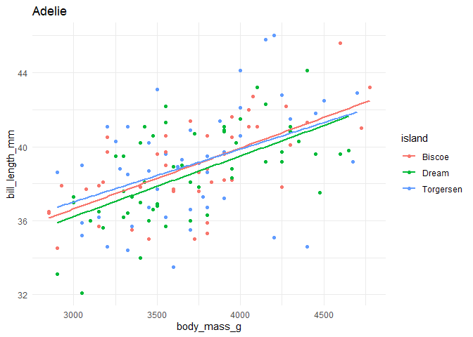

```r
tar_read(adelie_plot)
```

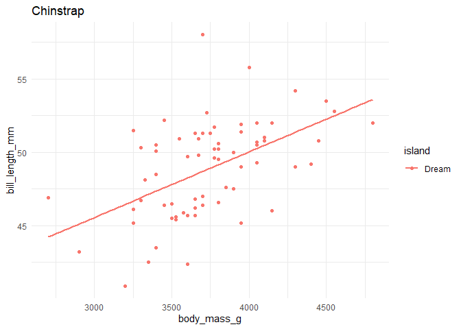

```r
tar_read(chinstrap_plot)
```

Targets is also compatible with within-function parallelism, so we can build functions using *future* as seen previously, and the workers will distribute between tasks and branches to minimize downtime in the code.

Let’s add a new function to calculate the linear coefficient between the bill length and body mass of our species, using within-function parallelism

```r
tar_option_set(packages = c("tidyverse","palmerpenguins","future","furrr"))
```

```
## Establish _targets.R and _targets_r/globals/options3.R.
```

```r
# clean data
data_clean = function(x,
                      sp = NULL,
                      isl = NULL){

  if(!identical(x,penguins)){
    return("The only acceptable input is penguins")
  }

  res = x %>%
    drop_na()

  if(!is.null(sp)){
     if(sp %in% c("Adelie","Chinstrap","Gentoo")){
       res = res %>%
        filter(species == sp)
       }else{
         return("Accepted species are Adelie, Chinstrap and Gentoo")
       }
    }

  if(!is.null(isl)){
    if(isl %in% c("Biscoe","Dream","Torgersen")){
      res = res %>%
        filter(island == isl)
    }else{
        return("Accepted islands are Biscoe, Dream and Torgersen")
      }
  }

  return(res)
}

# plot data
plot_species = function(x){
  x %>%
    ggplot(aes(x=body_mass_g,
               y=bill_length_mm,
               col=island)) +
            geom_point()+
            geom_smooth(method="lm",se=F)+
            theme_minimal()+
            ggtitle(paste(unique(x$species), collapse = " "))

}

# model data

mass2bill_coef = function(...){
  coefs = future_map(list(...),function(X){
    fit = lm(bill_length_mm~body_mass_g, data=X)
    return(data.frame(sp = X$species[1], coef = fit$coefficients[2]))
  })
  return(coefs)
}
```

```
## Establish _targets.R and _targets_r/globals/function3.R.
```

Then adjust our pipeline

```r
list(
  tar_target(data, palmerpenguins::penguins),

  tar_target(adelie, data_clean(data,
                                sp="Adelie")),

  tar_target(chinstrap, data_clean(data,
                                   sp="Chinstrap")),

  tar_target(adelie_plot, plot_species(adelie)),

  tar_target(chinstrap_plot, plot_species(chinstrap)),

  tar_target(mass2bill, mass2bill_coef(adelie,chinstrap))
)
```

```
## Establish _targets.R and _targets_r/targets/list_def3.R.
```

We should now see that our new target depends on 2 prior targets, so changing anything in the definition of them will force the coefficients to be re-estimated.

```r
tar_visnetwork()
```

[interactive chart not shown]

```r
tar_make_future()
```

```
## v skip target data
## v skip target adelie
## v skip target adelie_plot
## v skip target chinstrap
## v skip target chinstrap_plot
## * start target mass2bill
## * built target mass2bill
## * end pipeline
## Messages d'avis :
## 1: le package 'targets' a été compilé avec la version R 4.1.2
## 2: le package 'palmerpenguins' a été compilé avec la version R 4.1.2
## 3: le package 'future' a été compilé avec la version R 4.1.2
## 4: le package 'furrr' a été compilé avec la version R 4.1.2
## 5: 1 targets produced warnings. Run tar_meta(fields = warnings) for the messages.
```

```r
tar_read(mass2bill)
```

```
## [[1]]
##                 sp        coef
## body_mass_g Adelie 0.003159889
##
## [[2]]
##                    sp        coef
## body_mass_g Chinstrap 0.004462694
```

Because *targets* understands dependencies among functions, it is easier to prove that all outputs are synchronized with the latest version of your functions, parameters, etc.

This can be a major asset for reproducibility by giving a proof that the data really goes from point A to point B versus literate programming such as RMarkdown that is more prone to errors in complexe iterative coding exercises.

**Sadly, there are downsides to every tools.**

Most of us wouldn’t consider ourselves programmers or developpers… We are environmental scientists. Is it really reasonnable to write almost a complete packages worth of functions everytime we do something?

There is a reason why we often use R as we do, so its really your responsibility to question whether or not this would be beneficial to your work.

Still, to make the democratisation of *targets* easier, the developpers behind the project are working on what they call the **R Targetopia**. A group of extensions to targets to make large pipelines easier to deploy, adapting targets to other packages like *Rstan* using *stantargets*, or even using *target factories* that allows users to deploy massive pipelines as single targets, nesting multiple others.

Those approaches are especially efficient if you or your group or your community plans on using similar pipelines often, simply recycling most of the work and saving huge amounts of time.

Finally, recent *targets* development includes the *target markdown* extension that brings the *target* universe into the literate style of rmarkdown, allowing to narrate pipeline construction and interact with them in a notebook interface. *target markdown* was used in constructing this markdown document. Specific information can be found [here](https://books.ropensci.org/targets/markdown.html)

### [Optionnal section about progressr / beepr]

progressr: unifying API for progress updates, working with futures, purrr, lapply, foreach, for/while loops

easy functions for developpers and end users that works with shiny beepr, add sounds to progress evaluation

```r
my_function = function(x){
  p = progressor(along(x))
  y = future_lapply(x, function(z){
    p(paste0("z=",z, " by ", Sys.getpid()))
    some_function(z)
  })
  sum(y)
}

handlers("progress", "beepr")
plan(multisession)
with_progress(y = my_function(x))
```